# Identifying Fraud From Enron Email

A nanodegree project for Intro to Machine Learning.

```python
#!/usr/bin/python

import sys
import pickle
sys.path.append("../tools/")

from feature_format import featureFormat, targetFeatureSplit
from tester import dump_classifier_and_data
from pprint import pprint

import numpy as np
```

```python
### Load the dictionary containing the dataset
data_dict = pickle.load(open("final_project_dataset.pkl", "r") )
```

# Part One - Understanding the Dataset and Question

## Data Exploration

To better understand the dataset, an exploration is performed here and the results are summarized as following,

- there are 146 data points with 21 features, and a total of 3066 obervations.
- there are 18 people who is an point of interest.
- 1,358 data points are missing.
- the top 3 features with most missing values are "loan_advances", "director_fees", and "restricted_stock_deferred".

More detailed exploration and analysis are listed as below.

```python
# number of data points
len(data_dict.keys())
```

```
146
```

```python
# number of features available
len(data_dict['METTS MARK'])
```

```
21
```

```python
# available features
data_dict["METTS MARK"].keys()
```

```
['salary',
 'to_messages',
 'deferral_payments',
 'total_payments',
 'exercised_stock_options',
 'bonus',
 'restricted_stock',
 'shared_receipt_with_poi',
 'restricted_stock_deferred',
 'total_stock_value',
 'expenses',
 'loan_advances',
 'from_messages',
 'other',
 'from_this_person_to_poi',
 'poi',
 'director_fees',
 'deferred_income',
 'long_term_incentive',
 'email_address',
 'from_poi_to_this_person']
```

```python
# people of interest
count = 0
for key, item in data_dict.iteritems():
    if item["poi"]:
        print key
        count += 1
count
```

```
HANNON KEVIN P
COLWELL WESLEY
RIEKER PAULA H
KOPPER MICHAEL J
SHELBY REX
DELAINEY DAVID W
LAY KENNETH L
BOWEN JR RAYMOND M
BELDEN TIMOTHY N
FASTOW ANDREW S
CALGER CHRISTOPHER F
RICE KENNETH D
SKILLING JEFFREY K
YEAGER F SCOTT
HIRKO JOSEPH
KOENIG MARK E
CAUSEY RICHARD A
GLISAN JR BEN F
```

```
18
```

```python
# create a dictionary for all missing values
missing = {}
for key, item in data_dict.iteritems():
    for elem, value in item.iteritems():
        if value == "NaN":
            if elem not in missing:
                missing[elem] = 1
            else:
                missing[elem] += 1
```

```python
# number of missing values
number_of_missing = 0
for key, item in missing.iteritems():
    number_of_missing += item
number_of_missing
```

```
1358
```

```python
missing
```

```
{'bonus': 64,
 'deferral_payments': 107,
 'deferred_income': 97,
 'director_fees': 129,
 'email_address': 35,
 'exercised_stock_options': 44,
 'expenses': 51,
 'from_messages': 60,
 'from_poi_to_this_person': 60,
 'from_this_person_to_poi': 60,
 'loan_advances': 142,
 'long_term_incentive': 80,
 'other': 53,
 'restricted_stock': 36,
 'restricted_stock_deferred': 128,
 'salary': 51,
 'shared_receipt_with_poi': 60,
 'to_messages': 60,
 'total_payments': 21,
 'total_stock_value': 20}
```

```python
# check who isn't missing the feature 'load_advances'
# outputs the person's name and a boolean value indicated whether the person is a poi.
for key, item in data_dict.iteritems():
    if item["loan_advances"] != "NaN":
        print "name: ", key, ",poi:", item["poi"]
```

```
name:  LAY KENNETH L ,poi: True
name:  PICKERING MARK R ,poi: False
name:  TOTAL ,poi: False
name:  FREVERT MARK A ,poi: False
```

```python
# check who isn't missing the feature 'director_fees'
# outputs the person's name and a boolean value indicated whether the person is a poi.
for key, item in data_dict.iteritems():
    if item["director_fees"] != "NaN":
        print "name:", key, ",poi:", item["poi"]
```

```
name: CHAN RONNIE ,poi: False
name: BELFER ROBERT ,poi: False
name: URQUHART JOHN A ,poi: False
name: MENDELSOHN JOHN ,poi: False
name: WAKEHAM JOHN ,poi: False
name: POWERS WILLIAM ,poi: False
name: DUNCAN JOHN H ,poi: False
name: LEMAISTRE CHARLES ,poi: False
name: MEYER JEROME J ,poi: False
name: PEREIRA PAULO V. FERRAZ ,poi: False
name: BLAKE JR. NORMAN P ,poi: False
name: TOTAL ,poi: False
name: JAEDICKE ROBERT ,poi: False
name: WINOKUR JR. HERBERT S ,poi: False
name: BHATNAGAR SANJAY ,poi: False
name: SAVAGE FRANK ,poi: False
name: GRAMM WENDY L ,poi: False
```

```python
# check who isn't missing the feature 'restricted_stock_deferred'
# outputs the person's name and a boolean value indicated whether the person is a poi.
for key, item in data_dict.iteritems():
    if item["restricted_stock_deferred"] != "NaN":
        print "name", key, ",poi:", item["poi"]
```

```
name PIPER GREGORY F ,poi: False
name LOWRY CHARLES P ,poi: False
name CHAN RONNIE ,poi: False
name BELFER ROBERT ,poi: False
name CLINE KENNETH W ,poi: False
name DETMERING TIMOTHY J ,poi: False
name BANNANTINE JAMES M ,poi: False
name GATHMANN WILLIAM D ,poi: False
name HAEDICKE MARK E ,poi: False
name NOLES JAMES L ,poi: False
name TOTAL ,poi: False
name ALLEN PHILLIP K ,poi: False
name JAEDICKE ROBERT ,poi: False
name REYNOLDS LAWRENCE ,poi: False
name BHATNAGAR SANJAY ,poi: False
name CARTER REBECCA C ,poi: False
name DERRICK JR. JAMES V ,poi: False
name BAY FRANKLIN R ,poi: False
```

```python
# check who isn't missing the feature 'deferral_payments'
# outputs the person's name and a boolean value indicated whether the person is a poi.
for key, item in data_dict.iteritems():
    if item["deferral_payments"] != "NaN":
        print "name:", key, ",poi:", item["poi"]
```

```
name: BAXTER JOHN C ,poi: False
name: MEYER ROCKFORD G ,poi: False
name: HORTON STANLEY C ,poi: False
name: PIPER GREGORY F ,poi: False
name: HUMPHREY GENE E ,poi: False
name: GIBBS DANA R ,poi: False
name: COLWELL WESLEY ,poi: True
name: MULLER MARK S ,poi: False
name: WALTERS GARETH W ,poi: False
name: BELFER ROBERT ,poi: False
name: RIEKER PAULA H ,poi: True
name: HAYES ROBERT E ,poi: False
name: DETMERING TIMOTHY J ,poi: False
name: SULLIVAN-SHAKLOVITZ COLLEEN ,poi: False
name: LINDHOLM TOD A ,poi: False
name: LAY KENNETH L ,poi: True
name: OLSON CINDY K ,poi: False
name: GAHN ROBERT S ,poi: False
name: HAEDICKE MARK E ,poi: False
name: BAZELIDES PHILIP J ,poi: False
name: BELDEN TIMOTHY N ,poi: True
name: THORN TERENCE H ,poi: False
name: FOY JOE ,poi: False
name: PRENTICE JAMES ,poi: False
name: GRAY RODNEY ,poi: False
name: NOLES JAMES L ,poi: False
name: TOTAL ,poi: False
name: WASAFF GEORGE ,poi: False
name: ALLEN PHILLIP K ,poi: False
name: SHARP VICTORIA T ,poi: False
name: BADUM JAMES P ,poi: False
name: REYNOLDS LAWRENCE ,poi: False
name: HIRKO JOSEPH ,poi: True
name: FREVERT MARK A ,poi: False
name: BAY FRANKLIN R ,poi: False
name: FUGH JOHN L ,poi: False
name: MARTIN AMANDA K ,poi: False
name: BUY RICHARD B ,poi: False
name: TAYLOR MITCHELL S ,poi: False
```

As shown above, it doesn't seem to have a clear pattern on whether a poi is missing a value or not. The investigation on missing values ends here, and the missing values will be replaced with '0' after feature formatting.

# Part Two - Outlier Investigation

## Remove the TOTAL Data Point

As we already known in mini projects, there is an outlier named "TOTAL" in this dataset. We will need to remove it before any further analysis.

```python
# remove the outlier 'TOTAL'
data_dict.pop("TOTAL")
```

```
{'bonus': 97343619,
 'deferral_payments': 32083396,
 'deferred_income': -27992891,
 'director_fees': 1398517,
 'email_address': 'NaN',
 'exercised_stock_options': 311764000,
 'expenses': 5235198,
 'from_messages': 'NaN',
 'from_poi_to_this_person': 'NaN',
 'from_this_person_to_poi': 'NaN',
 'loan_advances': 83925000,
 'long_term_incentive': 48521928,
 'other': 42667589,
 'poi': False,
 'restricted_stock': 130322299,
 'restricted_stock_deferred': -7576788,
 'salary': 26704229,
 'shared_receipt_with_poi': 'NaN',
 'to_messages': 'NaN',
 'total_payments': 309886585,
 'total_stock_value': 434509511}
```

## Plots of the Outliers

To understand the outliers in this dataset, plots are created by using salary against every other feature but poi, which is used to color data points in each plot. As a starting point, all the available features will be selected and put into the model. Later in this report, some features will be removed based on their PCA importance score.

```python
import pandas as pd

# create features for plots
# features_list is a list of strings, each of which is a feature name.
# The first feature must be "poi".
features_list = ['poi',
                 'salary',
                 'to_messages',
                 'deferral_payments',
                 'total_payments',
                 'exercised_stock_options',
                 'bonus',
                 'restricted_stock',
                 'shared_receipt_with_poi',
                 'restricted_stock_deferred',
                 'total_stock_value',
                 'expenses',
                 'loan_advances',
                 'from_messages',
                 'other',
                 'from_this_person_to_poi',
                 'director_fees',
                 'deferred_income',
                 'long_term_incentive',
                 'from_poi_to_this_person']

# format the dataset
data = featureFormat(data_dict, features_list)

# create a pandas dataframe
df = pd.DataFrame(data, columns = features_list)
```

In the following plots, blue color stands for poi, red color stands for non-poi.

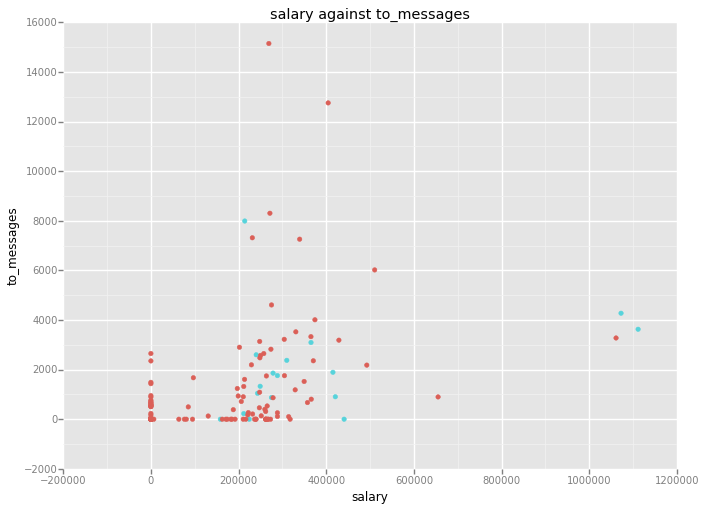

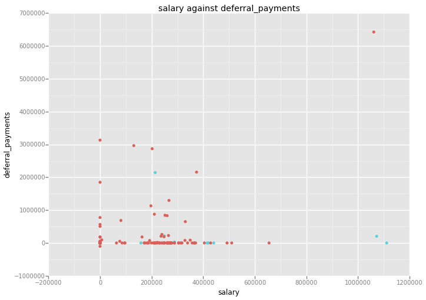

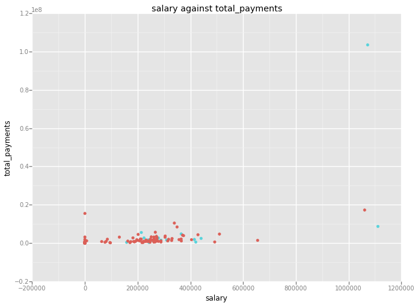

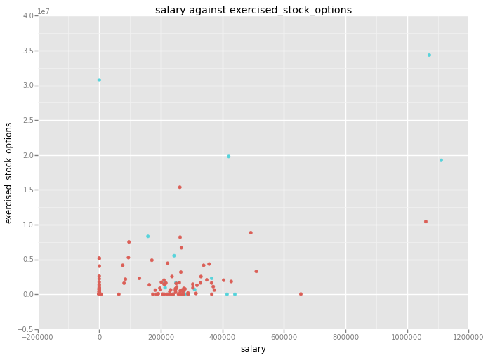

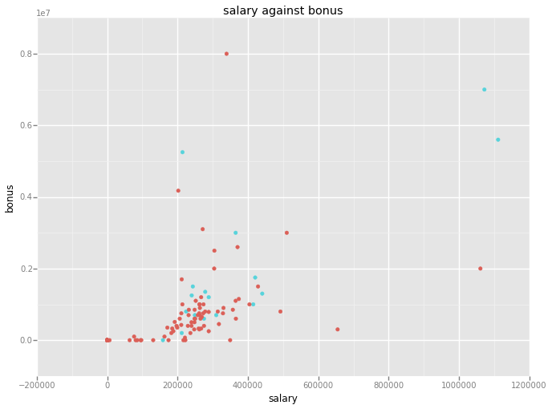

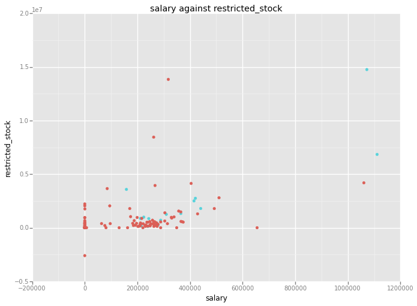

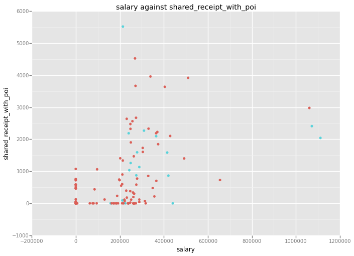

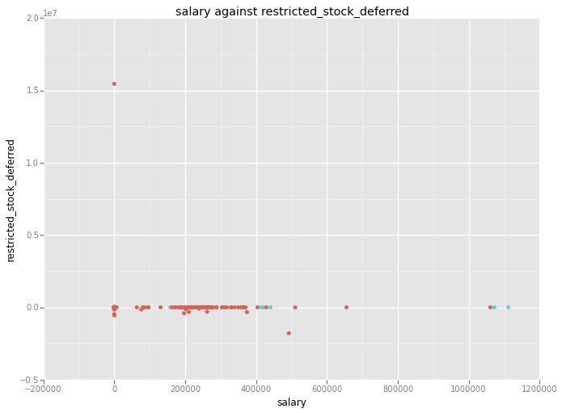

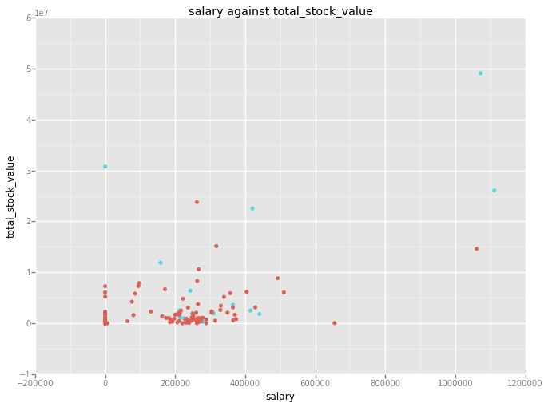

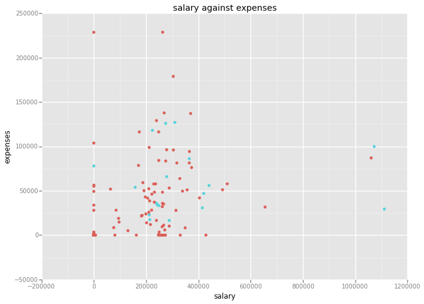

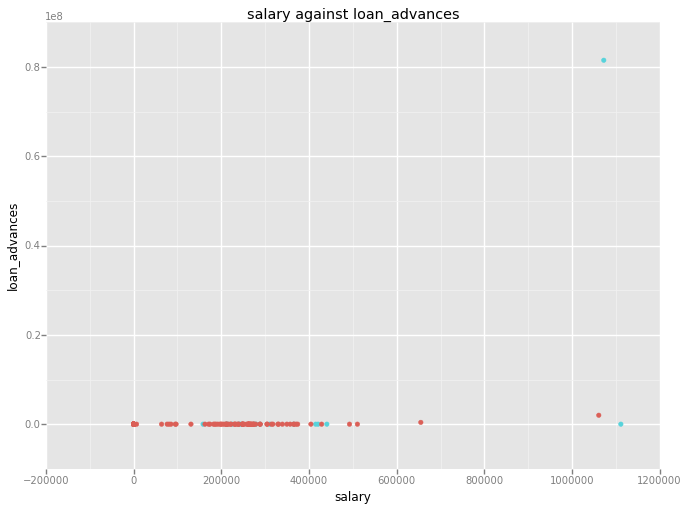

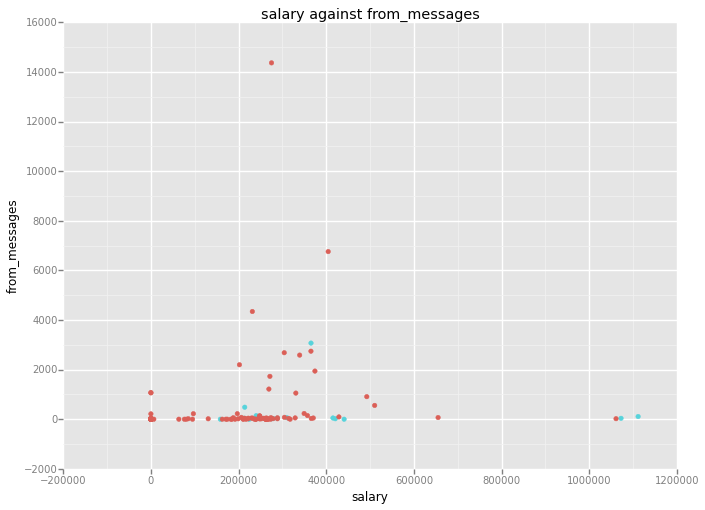

[6 more figures not shown]

```python
%matplotlib inline
from ggplot import *

# iter through all features
# x axis will always be salary
# poi is represented by colors of points
# the rest of features are put in y axis
for feature in features_list:
    if feature != "poi" and feature != "salary":
        print ggplot(aes(x = 'salary', y = feature, color = 'poi'),
               data = df) +\
        geom_point() +\
        ggtitle("salary against " + feature)
```

The purpose of removing outliers is to prevent the model being misrepresented by extreme cases, which comes with an assumption that either the extreme cases rarely happen, or they don't carry engough valuable infomration to be kept in the model. This can be true for some of the features, but could be controversy for "total_payment" feature, and shouldn't be applied to "exercised_stock_options" as the top four outliers are all person of interest. On the other hand, if we are to treat top 10% of each feature as outliers, it is not hard to imagine that the final dataset will have much less than 90%. A large deduction in the original dataset will cause the model beoming weaker.

Given all these thoughts, a detailed outliers removal is performed below.

## Remove Outliers

Instead of removing a certain percent of data points by each features directly, as a starting point, we will fit a dummy linear regression model, calculate the deviations, and treat data points with the highest deviations as outliers.

First of all, prepare features and labels.

```python
### Store to my_dataset for easy export below.
my_dataset = data_dict

### Extract features and labels from dataset for local testing
data = featureFormat(my_dataset, features_list, sort_keys = True)
labels, features = targetFeatureSplit(data)
```

Since we only want to remove the outliers by getting deviations from a linear model, there's no need to split the dataset as for now. The model is built as following,

```python
from sklearn.linear_model import LinearRegression
reg = LinearRegression()
reg.fit(features, labels)
predictions = reg.predict(features)
```

```python
### check the score
reg.score(features, labels)
```

```
0.356004646266603
```

Create the cleaner function.

```python
def outlierCleaner(predictions, features, labels):
    """
        clean away the 10% of points that have the largest
        residual errors (different between the prediction
        and the actual label value)

        return two lists - normals and outliers. Outliers
        are data points with the top 10% largest residual
        errors, the rest are in normals. Both of the lists
        are formatted as numpy array, and exactly like the
        formats after calling featureFormat.
    """

    normals = []
    outliers = []
    data = []
    length = int(len(predictions) * 0.9) + 1 # define the number of data points to be kept in normals

    ### create a dataset with a format:
    ### tuple(feature, label, residual errors)
    for i in range(len(predictions)):
        result = features[i], labels[i], (labels[i] - predictions[i]) ** 2
        data.append(tuple(result))

    ### sort dataset by deviations
    data.sort(key=lambda value: value[2])

    ### access dataset and create normals and outliers
    count = 0
    for values in data:
        count += 1
        if count <= length:
            normals.append(np.append([values[1]],values[0]))
        else:
            outliers.append(np.append([values[1]],values[0]))

    return normals, outliers
```

```python
### extract normal data points and outliers
cleaned_data, outliers = outlierCleaner(predictions, features, labels)
```

```python
### extract labels and features from cleaned_data
cleaned_labels, cleaned_features = targetFeatureSplit(cleaned_data)
```

```python
# fit the model again
reg.fit(cleaned_features, cleaned_labels)
# check the score
reg.score(cleaned_features, cleaned_labels)
```

```
0.82103305215836875
```

A removal of the outliers improved the score of the linear model dramastically from 0.35 to 0.82. Although it's good to see improvement in score, it's always necessary to take a look at the removed outliers.

## Find the Outliers

Although the featureFormat function creates a convenience here by turning a python dictionary into a numpy array, it also creates a difficulty checking who's been removed, as it loses information on keys of the dictionary after processing it. Moreover, the final test for this project uses my_dataset as an input, which is a python dicionary. If the removal of outliers do not happen on my_dataset, the test won't reflect the cleaning effort. Therefore, it's necessay to reformat the numpy array into a python dictionary.

```python
def featureReformat(numpy_array, features):
    """
        Format a numpy array object into a python
        dictionary object.

        Take a numpy array and features as inputs and
        return a python dictionary using features as
        keys and numpy array as values.
    """

    result = []

    for array in numpy_array:
        data_point = {}
        for i in range(len(features)):
            value = array[i]
            key = features[i]
            data_point[key] = value
        result.append(data_point)

    return result
```

```python
def personMapping(dict_list, dataset):
    """
        Mapping a person's name based on the values of
        features.

        Take a list of dictionaries that has all the values
        of person's features, and map it with a dataset
        which has a person's name as a key, and its features
        and values as the key's item.

        Return a dictionary with a person's name as its key,
        and another dictionary as its value, which has features
        as its key, and values of features as its values,
        {name_of_person_1:
            {feature_1: value,
             feature_2: value,
             feature_3: value,
             ...},
         name_of_person_2:
             {...}}
    """

    my_dataset = {}

    ### iter through the dataset
    for key, item in dataset.iteritems():

        ### open the dictionary list
        for data in dict_list:

            ### open the features list
            for feature in features_list:

                ### filter out 'NaN' in the dataset
                ### check all the '0' values
                if item[feature] == "NaN":
                    if int(data[feature]) == 0:
                        find = True
                    else:
                        find = False
                        break

                else:
                    ### check every other feature between dictionary list and dataset
                    ### using a logical value 'find' to determine if a match is found
                    if int(data[feature]) == item[feature]:
                        find = True
                    else:
                        find = False
                        break

            ### iter through all features once
            ### if found, map the data to my_dataset
            if find:
                my_dataset[key] = item

    return my_dataset
```

## Summary of Outliers

```python
outliers_dataset = personMapping(featureReformat(outliers, features_list), data_dict)
```

```python
len(outliers_dataset)
```

```
14
```

```python
for key, item in outliers_dataset.iteritems():
    if item['poi'] == 0.0:
        print key
```

```
LAVORATO JOHN J
```

## Create New Datasets

As mentioned above, simply removing the outliers might cause an issue for later on analysis. While the imporvement in score of the linear model is surely tempting, do note that, this is not the model that we will use to conduct machine learning in this dataset. However, since we don't want to miss any possible improvements in our future models, we will use both datasets in later analysis.

```python
my_full_dataset = data_dict
my_cleaned_dataset = personMapping(featureReformat(cleaned_data, features_list), data_dict)
```

```python
def featureLabelSplit(my_dataset, features_list):
    """
        A simple function creates features and labels

        Return features and labels
    """
    data = featureFormat(my_dataset, features_list, sort_keys = True)
    labels, features = targetFeatureSplit(data)
    return features, labels
```

On the other hand, there's no surprising that most of the person of interest might be flagged as outliers given the background knowledge of Enron Fraud. In this case, the outliers are the targets we want to find, according to [this post in discussion forum](https://discussions.udacity.com/t/outlier-removal/7446), we can manually decided to include or exclude the outliers or not in the training set. This strategy will be applied when processing the dataset.

# Part Three - Optimize Feature Selection

## Create New Features

To dig out more patterns from the dataset, three new features, "stock_salary_ratio", "poi_from_ratio", "poi_to_ratio", are created as following.

### Feature stock_salary_ratio

stock_salary_ratio takes the result from total_stock_value divided by salary. This feature is useful based on the assumption that a person of interest usually has a unusual large stock value since it's under the table, while salary information could be more easily known by public, thus the ratio could give information to identify the poi. The bigger the ratio, the more likely it is a poi.

### Feature poi_from_ratio and poi_to_ratio

poi_from_ratio takes result from from_poi_to_this_person divided by from_messages. This feature assumes that if a person is a poi, he/she tends to have more contacts with another poi, therefore the ratio would be bigger. And same applie to feature poi_to_ratio.

```python
### add new features to dataset
for key, item in data_dict.iteritems():
    ### add stock_salary_ratio
    if item['salary'] != "NaN" and item['total_stock_value'] != "NaN":
        item['stock_salary_ratio'] = float(item['total_stock_value']) / item['salary']
    else:
        item['stock_salary_ratio'] = "NaN"

    ### add poi_from_ratio
    if item['from_messages'] != "NaN" and item['from_poi_to_this_person'] != "NaN":
        item['poi_from_ratio'] = float(item['from_poi_to_this_person']) / item['from_messages']
    else:
        item['poi_from_ratio'] = "NaN"

    ### add poi_to_ratio
    if item["to_messages"] != "NaN" and item["from_this_person_to_poi"] != "NaN":
        item["poi_to_ratio"] = float(item["from_this_person_to_poi"]) / item["to_messages"]
    else:
        item["poi_to_ratio"] = "NaN"
```

```python
### update dataset
my_full_dataset = data_dict
my_cleaned_dataset = personMapping(featureReformat(cleaned_data, features_list), data_dict)
```

```python
### update features_list
features_list += ["stock_salary_ratio", "poi_from_ratio", "poi_to_ratio"]
```

## Feature Scaling

Depending on the algorithms chosen, feature scaling may be necessary. We will perform feature scaling anyway in case it is needed for later algorithms.

```python
### Extract features and labels from dataset for local testing
data = featureFormat(data_dict, features_list, sort_keys = True)
labels, features = targetFeatureSplit(data)
```

```python
from sklearn.preprocessing import MinMaxScaler
min_max_scaler = MinMaxScaler()
features = min_max_scaler.fit_transform(features)
```

## Feature Selection

To get a comprehensive processing before any fitting into models, a variety of feature selection methods for classification listed in [sklearn documentations](http://scikit-learn.org/stable/modules/feature_selection.html) are explored.

### K-Best

```python
from sklearn.feature_selection import SelectKBest
k_best = SelectKBest(k = 5)
k_best_features = k_best.fit_transform(features, labels)
```

```python
k_best_features.shape
```

```
(144, 5)
```

```python
k_best_result = zip(features_list[1:], k_best.scores_, k_best.get_support())
k_best_result.sort(key=lambda value:value[1], reverse=True)
```

### LinearSVC

```python
from sklearn.svm import LinearSVC
svc = LinearSVC(penalty="l1", dual=False, random_state=31)
svc_features = svc.fit_transform(features, labels)
```

```python
svc_features.shape
```

```
(144, 11)
```

```python
svc_result = zip(features_list[1:], svc.coef_[0])
svc_result.sort(key=lambda value:value[1], reverse=True)
```

### Randomized Logistic Regression

```python
from sklearn.linear_model import RandomizedLogisticRegression
randomized_logistic = RandomizedLogisticRegression(C=1, selection_threshold=0.01, random_state=31)
randomized_features = randomized_logistic.fit_transform(features, labels)
```

```python
randomized_features.shape
```

```
(144, 5)
```

```python
randomized_result = zip(features_list[1:], randomized_logistic.scores_, randomized_logistic.get_support())
randomized_result.sort(key=lambda value:value[1], reverse=True)
```

### Extra Tree Classifier

```python
from sklearn.ensemble import ExtraTreesClassifier
tree = ExtraTreesClassifier(max_features=5, random_state=31)
tree_features = tree.fit_transform(features, labels)
```

```python
tree_features.shape
```

```
(144, 10)
```

```python
tree_result = zip(features_list[1:], tree.feature_importances_)
tree_result.sort(key=lambda value: value[1], reverse=True)
```

### PCA

```python
from sklearn.decomposition import PCA
pca = PCA(n_components=5)
pca_features = pca.fit_transform(features, labels)
```

```python
pca_result = pca.explained_variance_ratio_
```

### Comparison Among Feature Selection Methods

```python
k_best_result
```

```
[('exercised_stock_options', 25.097541528735491, True),
 ('total_stock_value', 24.467654047526391, True),
 ('bonus', 21.060001707536578, True),
 ('salary', 18.575703268041778, True),
 ('deferred_income', 11.595547659732164, True),
 ('long_term_incentive', 10.072454529369448, False),
 ('restricted_stock', 9.3467007910514379, False),
 ('total_payments', 8.8667215371077805, False),
 ('shared_receipt_with_poi', 8.7464855321290802, False),
 ('loan_advances', 7.2427303965360172, False),
 ('expenses', 6.234201140506757, False),
 ('from_poi_to_this_person', 5.3449415231473347, False),
 ('poi_from_ratio', 5.2096502205817945, False),
 ('other', 4.2049708583014187, False),
 ('poi_to_ratio', 4.1690838152893894, False),
 ('from_this_person_to_poi', 2.4265081272428799, False),
 ('director_fees', 2.1076559432760891, False),
 ('to_messages', 1.6988243485808538, False),
 ('deferral_payments', 0.21705893033950563, False),
 ('from_messages', 0.16416449823428589, False),
 ('stock_salary_ratio', 0.11604758028880087, False),
 ('restricted_stock_deferred', 0.064984311723709831, False)]
```

```python
svc_result
```

```
[('exercised_stock_options', 1.0950838950406618),
 ('poi_to_ratio', 0.7466352145374815),
 ('poi_from_ratio', 0.36015916061596398),
 ('bonus', 0.29148395048848696),
 ('expenses', 0.2704577965056893),
 ('shared_receipt_with_poi', 0.2510705713943242),
 ('salary', 0.22289612051506077),
 ('total_payments', 0.0),
 ('restricted_stock', 0.0),
 ('restricted_stock_deferred', 0.0),
 ('total_stock_value', 0.0),
 ('loan_advances', 0.0),
 ('other', 0.0),
 ('from_this_person_to_poi', 0.0),
 ('director_fees', 0.0),
 ('long_term_incentive', 0.0),
 ('from_poi_to_this_person', 0.0),
 ('stock_salary_ratio', 0.0),
 ('to_messages', -0.06587235219815793),
 ('from_messages', -0.47974843716964488),
 ('deferred_income', -0.9828915681436613),
 ('deferral_payments', -1.5933167644049815)]
```

```python
randomized_result
```

```
[('exercised_stock_options', 0.30499999999999999, True),
 ('bonus', 0.25, True),
 ('total_stock_value', 0.19500000000000001, True),
 ('salary', 0.17499999999999999, True),
 ('deferred_income', 0.14999999999999999, True),
 ('restricted_stock', 0.0050000000000000001, False),
 ('long_term_incentive', 0.0050000000000000001, False),
 ('to_messages', 0.0, False),
 ('deferral_payments', 0.0, False),
 ('total_payments', 0.0, False),
 ('shared_receipt_with_poi', 0.0, False),
 ('restricted_stock_deferred', 0.0, False),
 ('expenses', 0.0, False),
 ('loan_advances', 0.0, False),
 ('from_messages', 0.0, False),
 ('other', 0.0, False),
 ('from_this_person_to_poi', 0.0, False),
 ('director_fees', 0.0, False),
 ('from_poi_to_this_person', 0.0, False),
 ('stock_salary_ratio', 0.0, False),
 ('poi_from_ratio', 0.0, False),
 ('poi_to_ratio', 0.0, False)]
```

```python
tree_result
```

```
[('total_stock_value', 0.096944804527901315),
 ('bonus', 0.083198761754560688),
 ('exercised_stock_options', 0.081074575647920394),
 ('poi_from_ratio', 0.070477274902069592),
 ('shared_receipt_with_poi', 0.069230525572848756),
 ('deferred_income', 0.065155017643954011),
 ('other', 0.061158523922399934),
 ('restricted_stock', 0.060994742731560067),
 ('expenses', 0.045988529360283185),
 ('from_this_person_to_poi', 0.045885724115353674),
 ('total_payments', 0.043829310280404703),
 ('from_poi_to_this_person', 0.041757956730981025),
 ('poi_to_ratio', 0.040272738295065259),
 ('salary', 0.036359160103815867),
 ('stock_salary_ratio', 0.03556745580929975),
 ('long_term_incentive', 0.032738398087870178),
 ('from_messages', 0.028846439205461767),
 ('to_messages', 0.020922859245281682),
 ('deferral_payments', 0.020767640416763222),
 ('loan_advances', 0.0097902097902098223),
 ('restricted_stock_deferred', 0.0087679516250944809),
 ('director_fees', 0.00027140023090057333)]
```

```python
pca_result
```

```
array([ 0.31577711,  0.13648178,  0.10975212,  0.08498722,  0.07317934])
```

### Finalize Feature Selection and More

Also keep in mind that, the above analysis was done based on the whole dataset, not the cleaned dataset without outliers. Therefore, to automize the pipeline in the later report, a list of feature selection functions and a function to combine all the features are created.

```python
feature_selection = [('k_best', SelectKBest(k = 5)),
                     ('linear_svc_l1', LinearSVC(C=0.01, penalty="l1", dual=False, random_state=31)),
                     ('logistic_reg', RandomizedLogisticRegression(C=1, selection_threshold=0.01, random_state=31)),
                     ('extra_tree', ExtraTreesClassifier(max_features=5, random_state=31))]
```

```python
from sklearn.pipeline import FeatureUnion, Pipeline

### combine pca to feature selection
combined_feature = []
for method in feature_selection:
    new_method = FeatureUnion([('pca', PCA(n_components=5)), method])
    name = method[0] + "_with_pca"
    combined_feature.append((name, new_method))
```

```python
### update feature selection list
feature_selection += combined_feature
```

Although four different feature selection methods are chosen, their parameters could be tuned and a potential better result could be found too. But it will be left to future. On the other hand, a combination of the feature selection results is really a conservative way, and it's doubtful it would work. Anyway, we will let the score speak of itself.

# Part Four - Pick and Tune an Algorithm

According to [this cheat sheet in sklearn](http://scikit-learn.org/stable/tutorial/machine_learning_map/), there are at least four classification methods can be used,

- LinearSVC
- KNeighbors Classifier
- SVC
- Ensemble Classifers

In this report, we will check on LinearSVC, KNeighborsClassifier, and AdaBoostClassifier.

## LinearSVC

Parameters to be tuned:

- C: float, default = 1.0
- loss: "hinge" or "squared_hinge", default = "squared_hinge"
- penalty: "l1" or "l2", default = "l2"
- dual: boolean, prefer False when n_samples > n_features, default = True
- tol: float, default = 0.0001
- max_iter: integer, default = 1000

```python
linear_svc = LinearSVC(random_state=31, dual=False)

params_svc = {'linear_svc__C':[1e-2, 1e-1, 1, 1e2, 1e3],
              'linear_svc__penalty': ["l1", "l2"],
              'linear_svc__tol': [1e4, 1e3, 1e2, 1],
              'linear_svc__max_iter': [1e2, 1e3, 1e4, 1e5]}
```

## KNeighborsClassifier

Parameters to be tuned:

- n_neighbors: integer, default = 5
- weights: "uniform" or "distance", default = "uniform"
- algorithm: "auto", "ball_tree", "kd_tree" or "brute", default = "auto"
- leaf_size: integer, default = 30
- p, integer, 1 for manhattan_distance, 2 for euclidean_distance, default = 2

```python
from sklearn.neighbors import KNeighborsClassifier

k_neighbors = KNeighborsClassifier()

params_kneighbors = {'k_neighbors__n_neighbors': [1, 5, 10, 20, 50],
                     'k_neighbors__weights': ["uniform", "distance"],
                     'k_neighbors__algorithm':["ball_tree", "kd_tree", "brute"],
                     'k_neighbors__leaf_size': [2, 5, 10, 30, 50, 100],
                     'k_neighbors__p': [1,2]}
```

## AdaBoostClassifer

Parameters to be tuned:

- n_estimators: integer, default = 50
- learning_rate: float, default = 1
- algorithm: "SAMME" or "SAMME.R", default = "SAMME.R"

```python
from sklearn.ensemble import AdaBoostClassifier
from sklearn.tree import DecisionTreeClassifier

ada_boost = AdaBoostClassifier(random_state=31)

params_adaboost = {'ada_boost__base_estimator': [DecisionTreeClassifier(), None],
                   'ada_boost__n_estimators': [1, 5, 10, 20, 50, 100],
                   'ada_boost__algorithm': ['SAMME', 'SAMME.R'],
                   'ada_boost__learning_rate': [0.01, 0.03, 0.06, 0.1, 0.3, 0.6, 1, 3, 6, 10],
                   }
```

```python
classifiers = [('linear_svc', linear_svc, params_svc),
               ('k_neighbors', k_neighbors, params_kneighbors),
               ('ada_boost', ada_boost, params_adaboost)]
```

# Part Five - Validate and Evaluate

## Cross Validation

To prevent overfitting, a cross validation is needed to split the dataset into training and testing. We will use train_test_split method with a default test_size of 0.25.

```python
from sklearn.cross_validation import train_test_split

def trainTestSplit(my_dataset, features_list):
    """
        A training and testing set split function.

        Take my_dataset and features_list as input, call on
        featueLabelSplit to create features and labels. Then
        use train_test_split to split datasets.

        Return training and testing datasets.
    """

    features, labels = featureLabelSplit(my_dataset, features_list)

    features_train, features_test, labels_train, labels_test = train_test_split(
        features, labels, test_size=0.25, random_state=42)

    return features_train, features_test, labels_train, labels_test
```

## Evaluation

```python
from sklearn.metrics import accuracy_score, f1_score, precision_score, recall_score

def evaluateModel(y_true, y_pred):
    """
        A model evaluator.
        Calculate the model's accuracy score, f1 score,
        precision score, and recall score.

        Return scores and print out the scores as side effects.
    """

    accuracy = round(accuracy_score(y_true, y_pred), 3)
    f1 = round(f1_score(y_true, y_pred), 3)
    precision = round(precision_score(y_true, y_pred), 3)
    recall = round(recall_score(y_true, y_pred), 3)

    print """    Accuracy score: {}
    F1 score: {}
    Precision score: {}
    Recall score: {}""".format(accuracy, f1, precision, recall)

    return accuracy, f1, precision, recall
```

# Part Six - Find the Best Estimators

```python
from sklearn.grid_search import GridSearchCV

def tuneEstimator(pipeline, param, features_train, features_test, labels_train):
    """
        Tune the classifiers to find the best estimator.

        Return the best estimator, predictions and scores.
    """

    clf = GridSearchCV(pipeline, param)

    ### train the model
    clf.fit(features_train, labels_train)

    ### store the tuning results
    tuned_scores = clf.grid_scores_

    ### use the best estimator
    best_clf = clf.best_estimator_
    labels_pred = best_clf.predict(features_test)

    return best_clf, labels_pred, tuned_scores
```

```python
def trainModel(my_dataset, features_list, feature_selection=feature_selection,
               classifiers=classifiers, scaling=False):
    """
        A model training function.

        Take a dataset in python dictionary format, a list of
        features, a list of feature selection methods, and a
        list of classification methods. Iter through each list
        and make combinations of different feature selection
        method with different classification method. Then use
        tuneEstimator to tune the model. Finally, it evaluates
        the model based on accuracy score, precision score,
        recall score, and f1 score.

        If scaling is True, it will scale features only when
        appropriate classifiers are used. If scaling_all is True,
        it will scale features for all classifiers.

        Return a list of models and tuned scores, and writes a csv
        file to store the results.
    """

    ### split the training and testing sets
    features_train, features_test, labels_train, labels_test = trainTestSplit(my_dataset, features_list)

    trained_model = []
    count = 0
    tuned_score = []
    model_results = []

    ### iter through feature selection and classification methods
    for selection_method in feature_selection:
        for item in classifiers:

            count += 1
            print "Model {} \n-working on classifier {}, using slection method {}".format(count, item[0],
                                                                                          selection_method[0])

            ### add a time function to calculate time used by each model
            from time import time
            t0 = time()

            ### unpack name, function and parameters
            classifier = item[:2]
            param = item[2]

            ### scale the features before training
            if scaling:
                features_train = MinMaxScaler().fit_transform(features_train)
                features_test = MinMaxScaler().fit_transform(features_test)

            try:

                ### build pipeline
                pipeline = Pipeline([selection_method, classifier[:2]])

                ### tune the model
                try:

                    print "--start tuning..."
                    clf, labels_pred, grid_scores = tuneEstimator(pipeline, param, features_train,
                                                                  features_test, labels_train)

                    ### store the tuning results
                    tuned_score.append(grid_scores)

                    ### store model's information, including name, function, and parameters
                    model_name = item[0] + " with " + selection_method[0]
                    model_info = (model_name, clf)
                    trained_model.append(model_info)

                    time_used = time() - t0
                    print "--training on {} complete, time used {}".format(model_name, time_used)

                    ### print out evaluation scores
                    accuracy, f1, precision, recall = evaluateModel(labels_test, labels_pred)

                    ### check the which dataset
                    if len(my_dataset) > 140:
                        cleaned = False
                    else:
                        cleaned = True
                    ### store the information of models
                    model_results.append((cleaned, count, scaling, selection_method[0], item[0], accuracy, f1,
                           precision, recall, round(time_used, 3)))
                    print ""

                except Exception, e:
                    print "--error on tuning: \n", e, "\n"

            except Exception, e:
                print "-error on classifying: \n", e, "\n"

    ### dump the model information into a csv file
    dumpResult(model_results)

    return trained_model, tuned_score
```

```python
def dumpResult(data):
    """
        Take the results from running models and dump
        into a csv file named "result.csv"
    """
    import csv
    import os

    ordered_data = findBest(data)

    file_exists = os.path.isfile("result.csv")

    with open("result.csv", "a") as f:
        writer = csv.writer(f)

        ### write row for a new file
        if not file_exists:
            writer.writerow(["cleaned", "model", "scaled", "feature_selection_method",
                             "classification_method", "accuracy_score", "f1_score",
                             "precision_score", "recall_score", "time_used"])

        for model in ordered_data:
            writer.writerow(model)
```

```python
def findBest(data):
    """
        Take the results from running models and reorder
        the data first by its scores then by its runtime.

        Return a list of reordered data.
    """

    ordered_data = []

    ### find the biggest accuracy score
    accuracy = max(data, key=lambda value:value[5])[5]

    ### exclude model that has lower accuracy scores
    for model in data:
        if model[5] < accuracy:
            pass
        else:
            ordered_data.append(model)

    ### order by runtime
    ordered_data.sort(key=lambda value:value[-1])

    return ordered_data
```

## Run Estimators on Full Dataset

When runing the esimators on full dataset, there are 24 models generated seperately for scaled and non-scaled features. A comparison among the best choices is as following, listed as model number, feature selection method, classification method, accuracy score, F1 score, precision score, recall score, and time consumption.

```python
### scaled results
full_model_sets_scaled, tuned_score_1 = trainModel(my_full_dataset, features_list, scaling=True)
```

```
Model 1
-working on classifier linear_svc, using slection method k_best
--start tuning...
--training on linear_svc with k_best complete, time used 1.42401409149
    Accuracy score: 0.944
    F1 score: 0.5
    Precision score: 1.0
    Recall score: 0.333

Model 2
-working on classifier k_neighbors, using slection method k_best
--start tuning...
--training on k_neighbors with k_best complete, time used 3.64615011215
    Accuracy score: 0.917
    F1 score: 0.0
    Precision score: 0.0
    Recall score: 0.0

Model 3
-working on classifier ada_boost, using slection method k_best
--start tuning...
--training on ada_boost with k_best complete, time used 12.1166799068
    Accuracy score: 0.917
    F1 score: 0.0
    Precision score: 0.0
    Recall score: 0.0

Model 4
-working on classifier linear_svc, using slection method linear_svc_l1
--start tuning...
--error on tuning:
Invalid threshold: all features are discarded.

Model 5
-working on classifier k_neighbors, using slection method linear_svc_l1
--start tuning...
--error on tuning:
Invalid threshold: all features are discarded.

Model 6
```

[output cut: 142 more lines]

```
--start tuning...
--training on k_neighbors with extra_tree_with_pca complete, time used 16.8011660576
    Accuracy score: 0.917
    F1 score: 0.0
    Precision score: 0.0
    Recall score: 0.0

Model 24
-working on classifier ada_boost, using slection method extra_tree_with_pca
--start tuning...
--training on ada_boost with extra_tree_with_pca complete, time used 21.9717922211
    Accuracy score: 0.917
    F1 score: 0.0
    Precision score: 0.0
    Recall score: 0.0
```

```python
### non-scaled results
full_model_sets, tuned_score_1 = trainModel(my_full_dataset, features_list)
```

```
Model 1
-working on classifier linear_svc, using slection method k_best
--start tuning...
--training on linear_svc with k_best complete, time used 1.47424077988
    Accuracy score: 0.944
    F1 score: 0.5
    Precision score: 1.0
    Recall score: 0.333

Model 2
-working on classifier k_neighbors, using slection method k_best
--start tuning...
--training on k_neighbors with k_best complete, time used 3.8334300518
    Accuracy score: 0.806
    F1 score: 0.222
    Precision score: 0.167
    Recall score: 0.333

Model 3
-working on classifier ada_boost, using slection method k_best
--start tuning...
--training on ada_boost with k_best complete, time used 12.1655340195
    Accuracy score: 0.917
    F1 score: 0.0
    Precision score: 0.0
    Recall score: 0.0

Model 4
-working on classifier linear_svc, using slection method linear_svc_l1
--start tuning...
--training on linear_svc with linear_svc_l1 complete, time used 3.70850491524
    Accuracy score: 0.917
    F1 score: 0.0
    Precision score: 0.0
    Recall score: 0.0

Model 5
-working on classifier k_neighbors, using slection method linear_svc_l1
--start tuning...
--training on k_neighbors with linear_svc_l1 complete, time used 8.81541204453
```

[output cut: 160 more lines]

```
--start tuning...
--training on k_neighbors with extra_tree_with_pca complete, time used 16.9197800159
    Accuracy score: 0.944
    F1 score: 0.5
    Precision score: 1.0
    Recall score: 0.333

Model 24
-working on classifier ada_boost, using slection method extra_tree_with_pca
--start tuning...
--training on ada_boost with extra_tree_with_pca complete, time used 21.8490610123
    Accuracy score: 0.917
    F1 score: 0.0
    Precision score: 0.0
    Recall score: 0.0
```

## Run estimators on cleaned dataset.

Similar to running estimators on full dataset, there are attempts to generate 24 models. However, as shown below, when using combined_feature as the feature selection method, it kept saying missing classes, a futher investigation is needed to figure this out.

```python
### scaled results
cleaned_model_sets_scaled, tuned_score_2 = trainModel(my_cleaned_dataset, features_list, scaling=True)
```

```
Model 1
-working on classifier linear_svc, using slection method k_best
--start tuning...
--training on linear_svc with k_best complete, time used 1.5064060688
    Accuracy score: 0.97
    F1 score: 0.667
    Precision score: 1.0
    Recall score: 0.5

Model 2
-working on classifier k_neighbors, using slection method k_best
--start tuning...
--training on k_neighbors with k_best complete, time used 3.71021604538
    Accuracy score: 0.939
    F1 score: 0.5
    Precision score: 0.5
    Recall score: 0.5

Model 3
-working on classifier ada_boost, using slection method k_best
--start tuning...
--training on ada_boost with k_best complete, time used 2.43037700653
    Accuracy score: 0.939
    F1 score: 0.5
    Precision score: 0.5
    Recall score: 0.5

Model 4
-working on classifier linear_svc, using slection method linear_svc_l1
--start tuning...
--error on tuning:
Invalid threshold: all features are discarded.

Model 5
-working on classifier k_neighbors, using slection method linear_svc_l1
--start tuning...
--error on tuning:
Invalid threshold: all features are discarded.

Model 6
```

[output cut: 124 more lines]

```
--start tuning...
--training on k_neighbors with extra_tree_with_pca complete, time used 16.2978799343
    Accuracy score: 0.939
    F1 score: 0.5
    Precision score: 0.5
    Recall score: 0.5

Model 24
-working on classifier ada_boost, using slection method extra_tree_with_pca
--start tuning...
--training on ada_boost with extra_tree_with_pca complete, time used 12.0513608456
    Accuracy score: 0.939
    F1 score: 0.5
    Precision score: 0.5
    Recall score: 0.5
```

```python
### non-scaled results
cleaned_model_sets, tuned_score_2 = trainModel(my_cleaned_dataset, features_list)
```

```
Model 1
-working on classifier linear_svc, using slection method k_best
--start tuning...
--training on linear_svc with k_best complete, time used 1.58292198181
    Accuracy score: 0.939
    F1 score: 0.0
    Precision score: 0.0
    Recall score: 0.0

Model 2
-working on classifier k_neighbors, using slection method k_best
--start tuning...
--training on k_neighbors with k_best complete, time used 3.83636498451
    Accuracy score: 0.939
    F1 score: 0.0
    Precision score: 0.0
    Recall score: 0.0

Model 3
-working on classifier ada_boost, using slection method k_best
--start tuning...
--training on ada_boost with k_best complete, time used 2.59034085274
    Accuracy score: 0.97
    F1 score: 0.667
    Precision score: 1.0
    Recall score: 0.5

Model 4
-working on classifier linear_svc, using slection method linear_svc_l1
--start tuning...
--training on linear_svc with linear_svc_l1 complete, time used 3.52399706841
    Accuracy score: 0.909
    F1 score: 0.0
    Precision score: 0.0
    Recall score: 0.0

Model 5
-working on classifier k_neighbors, using slection method linear_svc_l1
--start tuning...
--training on k_neighbors with linear_svc_l1 complete, time used 9.8698580265
```

[output cut: 142 more lines]

```
--start tuning...
--training on k_neighbors with extra_tree_with_pca complete, time used 16.3870229721
    Accuracy score: 0.939
    F1 score: 0.0
    Precision score: 0.0
    Recall score: 0.0

Model 24
-working on classifier ada_boost, using slection method extra_tree_with_pca
--start tuning...
--training on ada_boost with extra_tree_with_pca complete, time used 10.916960001
    Accuracy score: 0.97
    F1 score: 0.667
    Precision score: 1.0
    Recall score: 0.5
```

## Summary of the Best Models

A table of the potential best choices is as below.

```python
pd.read_csv("result.csv")
```

|  | cleaned | model | scaled | feature_selection_method | classification_method | accuracy_score | f1_score | precision_score | recall_score | time_used |
| --- | --- | --- | --- | --- | --- | --- | --- | --- | --- | --- |
| 0 | False | 1 | True | k_best | linear_svc | 0.944 | 0.500 | 1 | 0.333 | 1.424 |
| 1 | False | 1 | False | k_best | linear_svc | 0.944 | 0.500 | 1 | 0.333 | 1.474 |
| 2 | False | 14 | False | k_best_with_pca | k_neighbors | 0.944 | 0.500 | 1 | 0.333 | 5.054 |
| 3 | False | 17 | False | linear_svc_l1_with_pca | k_neighbors | 0.944 | 0.500 | 1 | 0.333 | 10.154 |
| 4 | False | 11 | False | extra_tree | k_neighbors | 0.944 | 0.500 | 1 | 0.333 | 15.624 |
| 5 | False | 23 | False | extra_tree_with_pca | k_neighbors | 0.944 | 0.500 | 1 | 0.333 | 16.920 |
| 6 | False | 20 | False | logistic_reg_with_pca | k_neighbors | 0.944 | 0.500 | 1 | 0.333 | 109.164 |
| 7 | False | 8 | False | logistic_reg | k_neighbors | 0.944 | 0.500 | 1 | 0.333 | 443.944 |
| 8 | True | 1 | True | k_best | linear_svc | 0.970 | 0.667 | 1 | 0.500 | 1.506 |
| 9 | True | 13 | True | k_best_with_pca | linear_svc | 0.970 | 0.667 | 1 | 0.500 | 1.969 |
| 10 | True | 10 | True | extra_tree | linear_svc | 0.970 | 0.667 | 1 | 0.500 | 6.446 |
| 11 | True | 3 | False | k_best | ada_boost | 0.970 | 0.667 | 1 | 0.500 | 2.590 |
| 12 | True | 15 | False | k_best_with_pca | ada_boost | 0.970 | 0.667 | 1 | 0.500 | 3.621 |
| 13 | True | 10 | False | extra_tree | linear_svc | 0.970 | 0.667 | 1 | 0.500 | 6.520 |
| 14 | True | 22 | False | extra_tree_with_pca | linear_svc | 0.970 | 0.667 | 1 | 0.500 | 7.133 |
| 15 | True | 12 | False | extra_tree | ada_boost | 0.970 | 0.667 | 1 | 0.500 | 9.987 |
| 16 | True | 24 | False | extra_tree_with_pca | ada_boost | 0.970 | 0.667 | 1 | 0.500 | 10.917 |

As it turns out, the best estimator is linear_svc with k_best as feature selection performed on the outlier-cleaned dataset after feature scaling.

```python
### access the estimator
best_pipeline = cleaned_model_sets_scaled[0][1]
```

```python
best_pipeline
```

```
Pipeline(steps=[('k_best', SelectKBest(k=5, score_func=<function f_classif at 0x109a1c8c0>)), ('linear_svc', LinearSVC(C=100.0, class_weight=None, dual=False, fit_intercept=True,
     intercept_scaling=1, loss='squared_hinge', max_iter=100.0,
     multi_class='ovr', penalty='l1', random_state=31, tol=1, verbose=0))])
```

```python
### get the chosen features printed out
k_best = best_pipeline.steps[0][1]
k_best_result = zip(features_list[1:], k_best.scores_, k_best.get_support())
k_best_result.sort(key=lambda value:value[1], reverse=True)

[feature for feature in k_best_result if feature[2] == True]
```

```
[('exercised_stock_options', 319.53986776215822, True),
 ('total_stock_value', 211.69715825941967, True),
 ('bonus', 63.117660779894678, True),
 ('total_payments', 53.613771072522852, True),
 ('loan_advances', 46.030927835051536, True)]
```

# Part Seven - The Final Solution

After comparing among feature selection methods, classification methods, carefully tuning parameters for the methods, and working on both the full dataset and the outlier-cleaned dataset, the best and fastest model turned out to be outlier-cleaned dataset with SelectKBest as feature selection processor and LinearSVC as classification method. Parameters are as following,

- SelectKBest, k = 5.
- LinearSVC, C = 100, dual = False, penalty = 'l1', tol = 1, max_iter = 100.

```python
### prepare for the test
clf = best_pipeline
my_dataset = my_cleaned_dataset
```

```python
### dump for testing
dump_classifier_and_data(clf, my_dataset, features_list)
```

# Part Eight - Documentation

### Summarize for us the goal of this project and how machine learning is useful in trying to accomplish it. As part of your answer, give some background on the dataset and how it can be used to answer the project question. Were there any outliers in the data when you got it, and how did you handle those? [relevant rubric items: “data exploration”, “outlier investigation”]

The goal of this project is to identify whether a person is guilty for the notorious Enron Fraud, using publicly available information like finacial incomes and emails.

From oil-trading, bandwidth trading, and weather trading with market-to-market accounting, Enron has moved its hands to a variety of commodities, got in touch with politicians like George W. Bush, and caused a great loss to the public, including the California electricity shortage. All these information can be useful if text learning was applied, and certain patterns could be found out like, a pattern indicating a decision-making person could very likely be a person of interest. However, this is not applied in this analysis since it's a more advanced topic.

This analysis used a finacial dataset containing people's salary, stock information, and so on. During Enron Fraud, people like Jefferey Skilling, Key Lay, and Fastow all have dumped large amounts of stock options, and they are all guilty. This information can be very helpful to check on other person of interest, and can be easily refelected in the dataset. This is also where machine learning comes into play. By creating models which calculate relationships between a person of interest and its available quantitative data, machine learning tries to find and memorize a pattern that helps us identify a guilty person in the future.

There are certain outliers by each feature. To find out the outliers, a multivariable linear regression model was created. By removing data points with top 10% variance between predicted and real values, an outlier-cleaned dataset was built for the analysis. However, as there were lots person of interest appearing in the outliers, the original dataset was kept too. The analysis later on performed investigation on two datasets, and trained estimators on both.

### What features did you end up using in your POI identifier, and what selection process did you use to pick them? Did you have to do any scaling? Why or why not? As part of the assignment, you should attempt to engineer your own feature that does not come ready-made in the dataset -- explain what feature you tried to make, and the rationale behind it. (You do not necessarily have to use it in the final analysis, only engineer and test it.) In your feature selection step, f you used an algorithm like a decision tree, please also give the feature importances of the features that you use, and if you used an automated feature selection function like SelectKBest, please report the feature scores. [relevant rubric items: “create new features”, “properly scale features”, “intelligently select feature”]

There are five features in the final analysis after applying SelectKBest as feature selection.

- exercised_stock_options, with a score of 319.54
- total_stock_value, with a score of 211.70
- bonus, with a score of 63.12
- total_payments, 53.61
- loan_advances, 46.03

The feature selection method is picked after comparing to other three different feature selection methods, and performed with and without PCA. Feature scaling is used as it gives the fastest performance with highest scores, although there are good results without using scaling. The reason behind scaling is that, the huge difference in values between features like 'total_payments' and 'from_messages' or 'to_messages'. As features are not in the same scale, it's better to perform feature scaling before further analysis.

Three new features, "stock_salary_ratio", "poi_from_ratio", "poi_to_ratio", are created when analyzing the data.

stock_salary_ratio takes the result from total_stock_value divided by salary. This feature is useful based on the assumption that a person of interest usually has a unusual large stock value since it's under the table, while salary information could be more easily known by public, thus the ratio could give information to identify the poi. The bigger the ratio, the more likely it is a poi.

poi_from_ratio takes result from from_poi_to_this_person divided by from_messages. This feature assumes that if a person is a poi, he/she tends to have more contacts with another poi, therefore the ratio would be bigger. And same applie to feature poi_to_ratio.

### What algorithm did you end up using? What other one(s) did you try? How did model performance differ between algorithms? [relevant rubric item: “pick an algorithm”]

The final algorithm used is LinearSVC. There were three algorithms being picked and evaluated, and LinearSVC gave the fastest performance on the same scores. Part of the performance is attached as below.

```python
pd.read_csv("result.csv")
```

|  | cleaned | model | scaled | feature_selection_method | classification_method | accuracy_score | f1_score | precision_score | recall_score | time_used |
| --- | --- | --- | --- | --- | --- | --- | --- | --- | --- | --- |
| 0 | False | 1 | True | k_best | linear_svc | 0.944 | 0.500 | 1 | 0.333 | 1.424 |
| 1 | False | 1 | False | k_best | linear_svc | 0.944 | 0.500 | 1 | 0.333 | 1.474 |
| 2 | False | 14 | False | k_best_with_pca | k_neighbors | 0.944 | 0.500 | 1 | 0.333 | 5.054 |
| 3 | False | 17 | False | linear_svc_l1_with_pca | k_neighbors | 0.944 | 0.500 | 1 | 0.333 | 10.154 |
| 4 | False | 11 | False | extra_tree | k_neighbors | 0.944 | 0.500 | 1 | 0.333 | 15.624 |
| 5 | False | 23 | False | extra_tree_with_pca | k_neighbors | 0.944 | 0.500 | 1 | 0.333 | 16.920 |
| 6 | False | 20 | False | logistic_reg_with_pca | k_neighbors | 0.944 | 0.500 | 1 | 0.333 | 109.164 |
| 7 | False | 8 | False | logistic_reg | k_neighbors | 0.944 | 0.500 | 1 | 0.333 | 443.944 |
| 8 | True | 1 | True | k_best | linear_svc | 0.970 | 0.667 | 1 | 0.500 | 1.506 |
| 9 | True | 13 | True | k_best_with_pca | linear_svc | 0.970 | 0.667 | 1 | 0.500 | 1.969 |
| 10 | True | 10 | True | extra_tree | linear_svc | 0.970 | 0.667 | 1 | 0.500 | 6.446 |
| 11 | True | 3 | False | k_best | ada_boost | 0.970 | 0.667 | 1 | 0.500 | 2.590 |
| 12 | True | 15 | False | k_best_with_pca | ada_boost | 0.970 | 0.667 | 1 | 0.500 | 3.621 |
| 13 | True | 10 | False | extra_tree | linear_svc | 0.970 | 0.667 | 1 | 0.500 | 6.520 |
| 14 | True | 22 | False | extra_tree_with_pca | linear_svc | 0.970 | 0.667 | 1 | 0.500 | 7.133 |
| 15 | True | 12 | False | extra_tree | ada_boost | 0.970 | 0.667 | 1 | 0.500 | 9.987 |
| 16 | True | 24 | False | extra_tree_with_pca | ada_boost | 0.970 | 0.667 | 1 | 0.500 | 10.917 |

### What does it mean to tune the parameters of an algorithm, and what can happen if you don’t do this well? How did you tune the parameters of your particular algorithm? (Some algorithms do not have parameters that you need to tune -- if this is the case for the one you picked, identify and briefly explain how you would have done it for the model that was not your final choice or a different model that does utilize parameter tuning, e.g. a decision tree classifier). [relevant rubric item: “tune the algorithm”]

Tuning the algorithm means to find a better solution specificly for the current problem. If an algorithm is not tuned well, it could lower down the accuracy score, percision and recall scores, while increasing the runtime.

To tune the algorithm, a list of available parameters are put into a dictionary as keys, with a list of possible values as their values. Then GridSearchCV was conducted to search for the best solution among the given paramters. So the tuning result is limited by the range of values given to parameters, it is important to provide reasonable amount of values to be tuned while considering the time cost.

### What is validation, and what’s a classic mistake you can make if you do it wrong? How did you validate your analysis? [relevant rubric item: “validation strategy”]

Without validation, the training might be lead to be overfitting. To avoid it, train_test_split was used to split the dataset into training and testing set. That is an easy and quick way to do cross validation.

### Give at least 2 evaluation metrics and your average performance for each of them. Explain an interpretation of your metrics that says something human-understandable about your algorithm’s performance. [relevant rubric item: “usage of evaluation metrics”]

The evaluation metrics in this analysis used are accuaracy score, f1 score, precision score and recall score. The final model has an accuracy score of 0.97, which means 97% of the predictions are found to be true. With a precision score of 1.0, it tells us that if this model predicts one person as a poi, then he is truly a poi. On the other hand, with a recall score of 0.5, only half of all the poi could be found out by this model. Finally, there's always a tradeoff between precision and recall, f1 comes and measure how well the tradeoff is. With a f1 score of 0.67, this model is fairly robust, while more improvement might be applied in the future.